# Scrollytelling Project

Since the Industrial Revolution of the 18th century introduced mass production, and with it mass amounts of carbon emmissions, climate change has been mostly driven by humans. One of the ways we see climate change is in the increase in surface temperature as CO2 emmissions burn a hole in the ozone, letting more of the sun’s energy reach the surface of the earth.

The following data will examine the surface temperature (measured two meters above the ground) of Ireland from the year 1940 to present day to look at the effects of climate change on one particular area.

Here we can see the average monthly surface temperature of Ireland from 1940 to 2024.

Several Irish actions have been undertaken to reduce emissions for the health of its citizens and of the environment.

The Air Pollution Act of 1990 banned bituminous fuel and showed improvements in air quality in Dublin. This led to the act being expanded to surrounding areas to protect the health of all Irish citizens.

In the later 1990s and early 2000s, Ireland explored its wind energy options as a natural, clean energy resource.

These actions, and more, will help to reduce Ireland’s effect on climate change and hopefully reduce surface temps in future years.

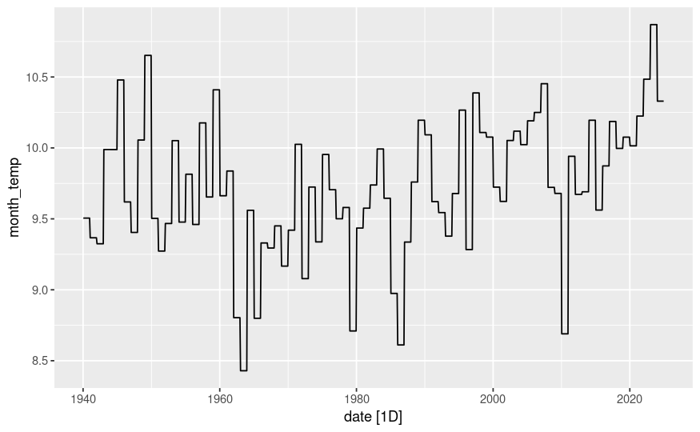

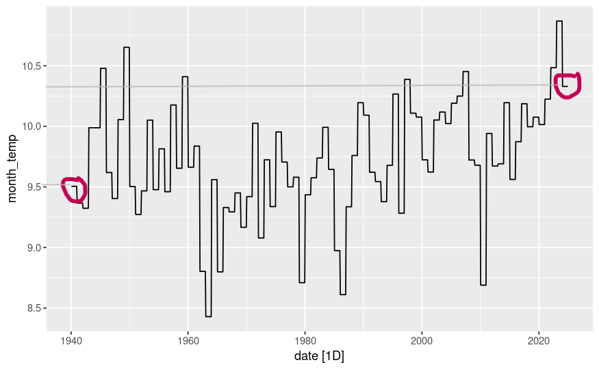

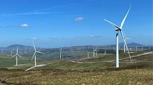

Sources

Data: https://www.kaggle.com/datasets/samithsachidanandan/average-monthly-surface-temperature-1940-2024/data

Ireland Energy Acts: https://irelandenergy2050.ie/past/